# Project: (Investigate a Dataset (TMDb Movie Data))

- Introduction
- Data Wrangling
- Exploratory Data Analysis
- Conclusions

## Introduction

I choose the TMDb movie data set for data analysis. This data set contains information about5000 movies collected from The Movie Database (TMDb), including user ratings and revenue.I would like to find other intresting patterns in the dataset.

Contain:

Total Rows = 4803 Total Columns = 20 After Seeing the dataset we can say that some columns is contain null values

## Questions

> What kinds of properties are associated with movies that have popularity ?

> Top 20 Production Companies With Higher Number Of Release?

```python
# Use this cell to set up import statements for all of the packages that you
#   plan to use.
import numpy as np
import pandas as pd
import matplotlib.pyplot as plt
import seaborn as sns
%matplotlib inline
from zipfile import ZipFile
# specifying the zip file name
file_name = "138_4508_bundle_archive.zip"
# opening the zip file in read mode
with ZipFile(file_name, 'r') as X:
# printing all the contents of the zip file
    X.printdir()
# extracting all the files
    X.extractall()

# Remember to include a 'magic word' so that your visualizations are plotted
#   inline with the notebook. See this page for more:
#   http://ipython.readthedocs.io/en/stable/interactive/magics.html
```

```
File Name                                             Modified             Size
tmdb_5000_credits.csv                          2019-09-19 18:34:00     40044293
tmdb_5000_movies.csv                           2019-09-19 18:34:04      5698602
```

## Data Wrangling

> After Observing the dataset and the questions related to this dataset for the analysis we will be keeping only relevent data and deleting the unused data.

### General Properties

```python
# Load your data and print out a few lines. Perform operations to inspect data
df_movies=pd.read_csv('tmdb_5000_movies.csv')
df_credits=pd.read_csv('tmdb_5000_credits.csv')
# View initial rows
df_movies.head(3)
```

|  | budget | genres | homepage | id | keywords | original_language | original_title | overview | popularity | production_companies | production_countries | release_date | revenue | runtime | spoken_languages | status | tagline | title | vote_average | vote_count |
| --- | --- | --- | --- | --- | --- | --- | --- | --- | --- | --- | --- | --- | --- | --- | --- | --- | --- | --- | --- | --- |
| 0 | 237000000 | [{"id": 28, "name": "Action"}, {"id": 12, "nam... | http://www.avatarmovie.com/ | 19995 | [{"id": 1463, "name": "culture clash"}, {"id":... | en | Avatar | In the 22nd century, a paraplegic Marine is di... | 150.437577 | [{"name": "Ingenious Film Partners", "id": 289... | [{"iso_3166_1": "US", "name": "United States o... | 2009-12-10 | 2787965087 | 162.0 | [{"iso_639_1": "en", "name": "English"}, {"iso... | Released | Enter the World of Pandora. | Avatar | 7.2 | 11800 |
| 1 | 300000000 | [{"id": 12, "name": "Adventure"}, {"id": 14, "... | http://disney.go.com/disneypictures/pirates/ | 285 | [{"id": 270, "name": "ocean"}, {"id": 726, "na... | en | Pirates of the Caribbean: At World's End | Captain Barbossa, long believed to be dead, ha... | 139.082615 | [{"name": "Walt Disney Pictures", "id": 2}, {"... | [{"iso_3166_1": "US", "name": "United States o... | 2007-05-19 | 961000000 | 169.0 | [{"iso_639_1": "en", "name": "English"}] | Released | At the end of the world, the adventure begins. | Pirates of the Caribbean: At World's End | 6.9 | 4500 |
| 2 | 245000000 | [{"id": 28, "name": "Action"}, {"id": 12, "nam... | http://www.sonypictures.com/movies/spectre/ | 206647 | [{"id": 470, "name": "spy"}, {"id": 818, "name... | en | Spectre | A cryptic message from Bond’s past sends him o... | 107.376788 | [{"name": "Columbia Pictures", "id": 5}, {"nam... | [{"iso_3166_1": "GB", "name": "United Kingdom"... | 2015-10-26 | 880674609 | 148.0 | [{"iso_639_1": "fr", "name": "Fran\u00e7ais"},... | Released | A Plan No One Escapes | Spectre | 6.3 | 4466 |

```python
df_movies.shape
```

```
(4803, 20)
```

```python
#   types and look for instances of missing or possibly errant data.
df_movies.info()
```

```
<class 'pandas.core.frame.DataFrame'>
RangeIndex: 4803 entries, 0 to 4802
Data columns (total 20 columns):
budget                  4803 non-null int64
genres                  4803 non-null object
homepage                1712 non-null object
id                      4803 non-null int64
keywords                4803 non-null object
original_language       4803 non-null object
original_title          4803 non-null object
overview                4800 non-null object
popularity              4803 non-null float64
production_companies    4803 non-null object
production_countries    4803 non-null object
release_date            4802 non-null object
revenue                 4803 non-null int64
runtime                 4801 non-null float64
spoken_languages        4803 non-null object
status                  4803 non-null object
tagline                 3959 non-null object
title                   4803 non-null object
vote_average            4803 non-null float64
vote_count              4803 non-null int64
dtypes: float64(3), int64(4), object(13)
memory usage: 750.5+ KB
```

```python
#showing a Sample of dataset
df_movies.sample(n =5)
```

|  | budget | genres | homepage | id | keywords | original_language | original_title | overview | popularity | production_companies | production_countries | release_date | revenue | runtime | spoken_languages | status | tagline | title | vote_average | vote_count |
| --- | --- | --- | --- | --- | --- | --- | --- | --- | --- | --- | --- | --- | --- | --- | --- | --- | --- | --- | --- | --- |
| 125 | 150000000 | [{"id": 12, "name": "Adventure"}, {"id": 28, "... | NaN | 604 | [{"id": 83, "name": "saving the world"}, {"id"... | en | The Matrix Reloaded | Six months after the events depicted in The Ma... | 70.785910 | [{"name": "Village Roadshow Pictures", "id": 7... | [{"iso_3166_1": "AU", "name": "Australia"}, {"... | 2003-05-15 | 738599701 | 138.0 | [{"iso_639_1": "en", "name": "English"}] | Released | Free your mind. | The Matrix Reloaded | 6.7 | 3443 |
| 1860 | 25000000 | [{"id": 28, "name": "Action"}, {"id": 80, "nam... | NaN | 2140 | [{"id": 90, "name": "paris"}, {"id": 549, "nam... | en | Kiss of the Dragon | Liu Jian, an elite Chinese police officer, com... | 16.936576 | [{"name": "Twentieth Century Fox Film Corporat... | [{"iso_3166_1": "FR", "name": "France"}, {"iso... | 2001-07-06 | 64437847 | 98.0 | [{"iso_639_1": "en", "name": "English"}, {"iso... | Released | Kiss Fear Goodbye | Kiss of the Dragon | 6.4 | 298 |
| 3484 | 0 | [{"id": 35, "name": "Comedy"}, {"id": 10402, "... | NaN | 13403 | [{"id": 108, "name": "transvestism"}, {"id": 2... | en | Hedwig and the Angry Inch | A transexual punk rock girl from East Berlin t... | 4.254220 | [{"name": "New Line Cinema", "id": 12}, {"name... | [{"iso_3166_1": "US", "name": "United States o... | 2001-07-20 | 0 | 95.0 | [{"iso_639_1": "en", "name": "English"}, {"iso... | Released | An anatomically incorrect rock odyssey | Hedwig and the Angry Inch | 7.4 | 80 |
| 3240 | 5000000 | [{"id": 27, "name": "Horror"}, {"id": 53, "nam... | NaN | 170 | [{"id": 212, "name": "london england"}, {"id":... | en | 28 Days Later | Twenty-eight days after a killer virus was acc... | 45.490374 | [{"name": "DNA Films", "id": 284}, {"name": "B... | [{"iso_3166_1": "GB", "name": "United Kingdom"}] | 2002-10-31 | 82719885 | 113.0 | [{"iso_639_1": "es", "name": "Espa\u00f1ol"}, ... | Released | His fear began when he woke up alone. His terr... | 28 Days Later | 7.1 | 1777 |
| 356 | 90000000 | [{"id": 28, "name": "Action"}, {"id": 12, "nam... | http://sherlock-holmes-movie.warnerbros.com/ | 10528 | [{"id": 703, "name": "detective"}, {"id": 770,... | en | Sherlock Holmes | Eccentric consulting detective, Sherlock Holme... | 57.834787 | [{"name": "Village Roadshow Pictures", "id": 7... | [{"iso_3166_1": "DE", "name": "Germany"}, {"is... | 2009-12-23 | 524028679 | 128.0 | [{"iso_639_1": "en", "name": "English"}, {"iso... | Released | Nothing escapes him. | Sherlock Holmes | 7.0 | 5766 |

```python
df_movies.describe()
```

|  | budget | id | popularity | revenue | runtime | vote_average | vote_count |
| --- | --- | --- | --- | --- | --- | --- | --- |
| count | 4.803000e+03 | 4803.000000 | 4803.000000 | 4.803000e+03 | 4801.000000 | 4803.000000 | 4803.000000 |
| mean | 2.904504e+07 | 57165.484281 | 21.492301 | 8.226064e+07 | 106.875859 | 6.092172 | 690.217989 |
| std | 4.072239e+07 | 88694.614033 | 31.816650 | 1.628571e+08 | 22.611935 | 1.194612 | 1234.585891 |
| min | 0.000000e+00 | 5.000000 | 0.000000 | 0.000000e+00 | 0.000000 | 0.000000 | 0.000000 |
| 25% | 7.900000e+05 | 9014.500000 | 4.668070 | 0.000000e+00 | 94.000000 | 5.600000 | 54.000000 |
| 50% | 1.500000e+07 | 14629.000000 | 12.921594 | 1.917000e+07 | 103.000000 | 6.200000 | 235.000000 |
| 75% | 4.000000e+07 | 58610.500000 | 28.313505 | 9.291719e+07 | 118.000000 | 6.800000 | 737.000000 |
| max | 3.800000e+08 | 459488.000000 | 875.581305 | 2.787965e+09 | 338.000000 | 10.000000 | 13752.000000 |

```python
df_movies.fillna(0)
```

[output not shown]

4803 rows × 20 columns

```python
df_movies['status'].value_counts()
```

```
Released           4795
Rumored               5
Post Production       3
Name: status, dtype: int64
```

```python
df_movies.duplicated().sum()
```

```
0
```

```python
df_movies['original_language'].value_counts()
```

```
en    4505
fr      70
es      32
de      27
zh      27
hi      19
ja      16
it      14
cn      12
ru      11
ko      11
pt       9
da       7
sv       5
fa       4
nl       4
th       3
he       3
ar       2
cs       2
id       2
ta       2
ro       2
pl       1
hu       1
nb       1
ky       1
ps       1
el       1
vi       1
te       1
no       1
sl       1
tr       1
is       1
af       1
xx       1
Name: original_language, dtype: int64
```

```python
df_movies['genres'][1]
```

```
'[{"id": 12, "name": "Adventure"}, {"id": 14, "name": "Fantasy"}, {"id": 28, "name": "Action"}]'
```

```python
df_movies.isnull().sum()
```

```
budget                     0
genres                     0
homepage                3091
id                         0
keywords                   0
original_language          0
original_title             0
overview                   3
popularity                 0
production_companies       0
production_countries       0
release_date               1
revenue                    0
runtime                    2
spoken_languages           0
status                     0
tagline                  844
title                      0
vote_average               0
vote_count                 0
dtype: int64
```

```python
print("Rows With Zero Values In The Budget Column:",df_movies[(df_movies['budget']==0)].shape[0])
print("Rows With Zero Values In The Revenue Column:",df_movies[(df_movies['revenue']==0)].shape[0])
print("Rows With Zero Values In The Revenue Column:",df_movies[(df_movies['runtime']==0)].shape[0])
```

[output not shown]

### Data Cleaning (Removing The Unused Information From The Dataset!)

Information That We Need To Delete Or Modify¶

We need to remove duplicate rows from the dataset Changing format of release date into datetime format Remove the unused colums that are not needes in the analysis process.

```python
# After discussing the structure of the data and any problems that need to be
#   cleaned, perform those cleaning steps in the second part of this section.
#droping unnassry columns
df_movies.drop(columns=['homepage','id','tagline','overview','spoken_languages','keywords','original_language'],inplace=True)
```

```python
#convert data type for string to Date Time
df_movies['release_date'] =  pd.to_datetime(df_movies['release_date'])
```

```python
#showing the shape after cleaning
df_movies.shape
```

```
(4803, 13)
```

```python
sum(df_movies.duplicated())
```

```
0
```

```python
df_movies.head(3)
```

|  | budget | genres | original_title | popularity | production_companies | production_countries | release_date | revenue | runtime | status | title | vote_average | vote_count |
| --- | --- | --- | --- | --- | --- | --- | --- | --- | --- | --- | --- | --- | --- |
| 0 | 237000000 | [{"id": 28, "name": "Action"}, {"id": 12, "nam... | Avatar | 150.437577 | [{"name": "Ingenious Film Partners", "id": 289... | [{"iso_3166_1": "US", "name": "United States o... | 2009-12-10 | 2787965087 | 162.0 | Released | Avatar | 7.2 | 11800 |
| 1 | 300000000 | [{"id": 12, "name": "Adventure"}, {"id": 14, "... | Pirates of the Caribbean: At World's End | 139.082615 | [{"name": "Walt Disney Pictures", "id": 2}, {"... | [{"iso_3166_1": "US", "name": "United States o... | 2007-05-19 | 961000000 | 169.0 | Released | Pirates of the Caribbean: At World's End | 6.9 | 4500 |
| 2 | 245000000 | [{"id": 28, "name": "Action"}, {"id": 12, "nam... | Spectre | 107.376788 | [{"name": "Columbia Pictures", "id": 5}, {"nam... | [{"iso_3166_1": "GB", "name": "United Kingdom"... | 2015-10-26 | 880674609 | 148.0 | Released | Spectre | 6.3 | 4466 |

```python
#function for clean string and geting the genres in list
def get_cat(string):
    categories = []
    for i, word in enumerate(string.split(" ")):
        if word == '"name":':
            value = string.split(" ")[i+1]
#to remove the double quotations and } and ,
            value = value.replace('"','')
            value = value.replace('}','')
            value = value.replace(',','')
            value = value.replace('{','')
            value = value.replace('[','')
            value = value.replace(']','')



            categories.append(value)
    return categories
```

```python
df_movies['genres']=df_movies['genres'].apply(get_cat)
```

```python
df_movies['genres'].head(1)
```

```
0    [Action, Adventure, Fantasy, Science]
Name: genres, dtype: object
```

```python
#df_movies.drop(columns=['genres'],inplace=True)
```

```python
df_movies.head(1)
```

|  | budget | genres | original_title | popularity | production_companies | production_countries | release_date | revenue | runtime | status | title | vote_average | vote_count |
| --- | --- | --- | --- | --- | --- | --- | --- | --- | --- | --- | --- | --- | --- |
| 0 | 237000000 | [Action, Adventure, Fantasy, Science] | Avatar | 150.437577 | [{"name": "Ingenious Film Partners", "id": 289... | [{"iso_3166_1": "US", "name": "United States o... | 2009-12-10 | 2787965087 | 162.0 | Released | Avatar | 7.2 | 11800 |

```python
for wn in df_movies['production_companies'][0].split(' '):
    print(wn)
```

```
[{"name":
"Ingenious
Film
Partners",
"id":
289},
{"name":
"Twentieth
Century
Fox
Film
Corporation",
"id":
306},
{"name":
"Dune
Entertainment",
"id":
444},
{"name":
"Lightstorm
Entertainment",
"id":
574}]
```

```python
#function for cleaning string
def clean_text(text):
    text = text.replace('{',' ')
    text=text.replace(',',' ')
    text=text.replace('"',' ')
    text=text.replace(':',' ')
    text=text.replace('}',' ')
    text=text.replace('[',' ')
    text=text.replace(']',' ')
    return text
```

```python
#function for gitting alist of company name
def get_company(text):
    text = clean_text(text).lower()
    x=text.split('    ')
    company_list = []
    for i, word in enumerate(x):
        #print(word)
        if "name" in word:
            company_name = x[i+1]
            company_list.append(company_name)
    return company_list
```

```python
df_movies['production_companies']=df_movies['production_companies'].apply(get_company)
```

```python
#for knowing more about companys
values = []
for company_list in df_movies['production_companies']:
    for company in company_list:
        if company not in values:
            values.append(company)
print(values)
```

[output not shown]

```python
len(df_movies)
```

```
4803
```

```python
df_movies['production_countries'][0]
```

```
'[{"iso_3166_1": "US", "name": "United States of America"}, {"iso_3166_1": "GB", "name": "United Kingdom"}]'
```

```python
#example1=df_movies['production_countries'][0]
```

```python
def get_country(text1):
    text1 = clean_text(text1)
    x=text1.split('    ')
    country_name=[]
    for o,world in enumerate(x):
        if 'name'in world:
            country=x[o+1]
            country_name.append(country)
    return country_name
```

```python
df_movies['production_countries']=df_movies['production_countries'].apply(get_country)
```

```python
df_movies.head(1)
```

|  | budget | genres | original_title | popularity | production_companies | production_countries | release_date | revenue | runtime | status | title | vote_average | vote_count |
| --- | --- | --- | --- | --- | --- | --- | --- | --- | --- | --- | --- | --- | --- |
| 0 | 237000000 | [Action, Adventure, Fantasy, Science] | Avatar | 150.437577 | [ingenious film partners, twentieth century fo... | [United States of America, United Kingdom ] | 2009-12-10 | 2787965087 | 162.0 | Released | Avatar | 7.2 | 11800 |

```python
df_movies.drop(df_movies[df_movies['budget']==0].index, inplace=True)
```

```python
df_movies.head()
```

|  | budget | genres | original_title | popularity | production_companies | production_countries | release_date | revenue | runtime | status | title | vote_average | vote_count |
| --- | --- | --- | --- | --- | --- | --- | --- | --- | --- | --- | --- | --- | --- |
| 0 | 237000000 | [Action, Adventure, Fantasy, Science] | Avatar | 150.437577 | [ingenious film partners, twentieth century fo... | [United States of America, United Kingdom ] | 2009-12-10 | 2787965087 | 162.0 | Released | Avatar | 7.2 | 11800 |
| 1 | 300000000 | [Adventure, Fantasy, Action] | Pirates of the Caribbean: At World's End | 139.082615 | [walt disney pictures, jerry bruckheimer films... | [United States of America ] | 2007-05-19 | 961000000 | 169.0 | Released | Pirates of the Caribbean: At World's End | 6.9 | 4500 |
| 2 | 245000000 | [Action, Adventure, Crime] | Spectre | 107.376788 | [columbia pictures, danjaq, b24] | [United Kingdom, United States of America ] | 2015-10-26 | 880674609 | 148.0 | Released | Spectre | 6.3 | 4466 |
| 3 | 250000000 | [Action, Crime, Drama, Thriller] | The Dark Knight Rises | 112.312950 | [legendary pictures, warner bros., dc entertai... | [United States of America ] | 2012-07-16 | 1084939099 | 165.0 | Released | The Dark Knight Rises | 7.6 | 9106 |
| 4 | 260000000 | [Action, Adventure, Science] | John Carter | 43.926995 | [walt disney pictures] | [United States of America ] | 2012-03-07 | 284139100 | 132.0 | Released | John Carter | 6.1 | 2124 |

```python
df_movies.drop(df_movies[df_movies['revenue']==0].index, inplace=True)
```

```python
df_movies.drop(df_movies[df_movies['runtime']==0].index, inplace=True)
```

```python
df_movies.shape
```

```
(3229, 13)
```

```python
df_movies['production_countries'].head(5)
```

```
0    [United States of America, United Kingdom   ]
1                    [United States of America   ]
2    [United Kingdom, United States of America   ]
3                    [United States of America   ]
4                    [United States of America   ]
Name: production_countries, dtype: object
```

```python
df_movies['production_companies'][1]
```

```
['walt disney pictures', 'jerry bruckheimer films', 'second mate productions']
```

```python
df_movies.head(10)
```

|  | budget | genres | original_title | popularity | production_companies | production_countries | release_date | revenue | runtime | status | title | vote_average | vote_count |
| --- | --- | --- | --- | --- | --- | --- | --- | --- | --- | --- | --- | --- | --- |
| 0 | 237000000 | [Action, Adventure, Fantasy, Science] | Avatar | 150.437577 | [ingenious film partners, twentieth century fo... | [United States of America, United Kingdom ] | 2009-12-10 | 2787965087 | 162.0 | Released | Avatar | 7.2 | 11800 |
| 1 | 300000000 | [Adventure, Fantasy, Action] | Pirates of the Caribbean: At World's End | 139.082615 | [walt disney pictures, jerry bruckheimer films... | [United States of America ] | 2007-05-19 | 961000000 | 169.0 | Released | Pirates of the Caribbean: At World's End | 6.9 | 4500 |
| 2 | 245000000 | [Action, Adventure, Crime] | Spectre | 107.376788 | [columbia pictures, danjaq, b24] | [United Kingdom, United States of America ] | 2015-10-26 | 880674609 | 148.0 | Released | Spectre | 6.3 | 4466 |
| 3 | 250000000 | [Action, Crime, Drama, Thriller] | The Dark Knight Rises | 112.312950 | [legendary pictures, warner bros., dc entertai... | [United States of America ] | 2012-07-16 | 1084939099 | 165.0 | Released | The Dark Knight Rises | 7.6 | 9106 |
| 4 | 260000000 | [Action, Adventure, Science] | John Carter | 43.926995 | [walt disney pictures] | [United States of America ] | 2012-03-07 | 284139100 | 132.0 | Released | John Carter | 6.1 | 2124 |
| 5 | 258000000 | [Fantasy, Action, Adventure] | Spider-Man 3 | 115.699814 | [columbia pictures, laura ziskin productions, ... | [United States of America ] | 2007-05-01 | 890871626 | 139.0 | Released | Spider-Man 3 | 5.9 | 3576 |
| 6 | 260000000 | [Animation, Family] | Tangled | 48.681969 | [walt disney pictures, walt disney animation s... | [United States of America ] | 2010-11-24 | 591794936 | 100.0 | Released | Tangled | 7.4 | 3330 |
| 7 | 280000000 | [Action, Adventure, Science] | Avengers: Age of Ultron | 134.279229 | [marvel studios, prime focus, revolution sun s... | [United States of America ] | 2015-04-22 | 1405403694 | 141.0 | Released | Avengers: Age of Ultron | 7.3 | 6767 |
| 8 | 250000000 | [Adventure, Fantasy, Family] | Harry Potter and the Half-Blood Prince | 98.885637 | [warner bros., heyday films] | [United Kingdom, United States of America ] | 2009-07-07 | 933959197 | 153.0 | Released | Harry Potter and the Half-Blood Prince | 7.4 | 5293 |
| 9 | 250000000 | [Action, Adventure, Fantasy] | Batman v Superman: Dawn of Justice | 155.790452 | [dc comics, atlas entertainment, warner bros.,... | [United States of America ] | 2016-03-23 | 873260194 | 151.0 | Released | Batman v Superman: Dawn of Justice | 5.7 | 7004 |

## Exploratory Data Analysis

> So, now, as the title suggests, we are ready for Exploratory Data Analysis. As we know, we need to form questions for further research and analysis, this part will help us form those questions after we explore deeper and try to look at some specific areas for research. We will do this part stepwise as we have been doing till now.

### Research Question 1 : What kinds of properties are associated with movies that have popularity ?¶

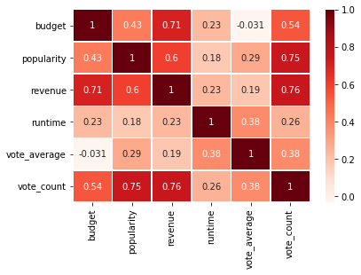

```python
# Use this, and more code cells, to explore your data. Don't forget to add
#   Markdown cells to document your observations and findings.
# investigate the corr
corr = df_movies.corr()
# plot the correlation
sns.heatmap(corr,
        xticklabels=corr.columns,
        yticklabels=corr.columns,
            annot=True, # Show dimensions in each cell
            cmap="Reds", # Set fill color: yellow, green, blue
            cbar=True,  # Show color bar
            linewidths=0.5, # Add small space between cells for easy data reading
           )
#plt.savefig('Box office correlation matrix.png',dpi=300)
```

> The popularity seems to be increasing with revenue . We can say that if the revenue of movie is high then the popularity of the movie may be high. Correlation = 0.6

> The correlation between Popularity and vote average is 0.29. So vote average is not highly related to the Popularity .

> The correlation between Popularity and runtime is 0.18. So runtime is not highly related to the Popularity.

```python
df_movies['production_companies'][0]
```

```
['ingenious film partners',
 'twentieth century fox film corporation',
 'dune entertainment',
 'lightstorm entertainment']
```

### Research Question 2 ( Top 20 Production Companies With Higher Number Of Release?)

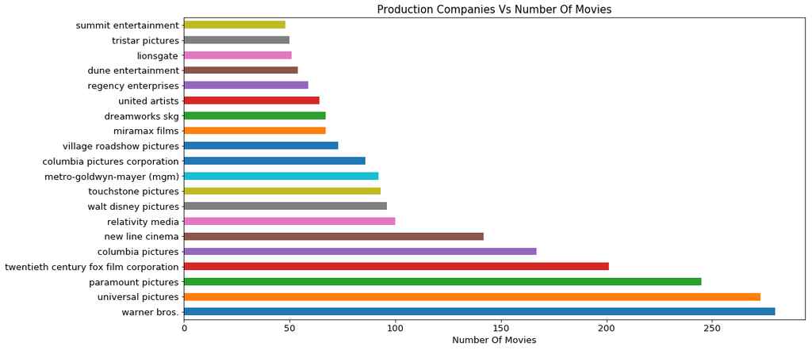

```python
# Continue to explore the data to address your additional research
#   questions. Add more headers as needed if you have more questions to
#   investigate
def companys_count(v):
    c=[]
    for x in df_movies[v]:
        for m in x:
            c.append(m)
            company=pd.Series(c)
    b=company.value_counts(ascending=False)
    return b
production_companies = companys_count('production_companies')
production_companies.iloc[:20].plot(kind='barh',figsize=(16,8),fontsize=13)
plt.title("Production Companies Vs Number Of Movies",fontsize=15)
plt.xlabel('Number Of Movies',fontsize=13)
sns.set_style("whitegrid")
```

## Conclusions

> Movies with higher popularity have shown a corresponding increase in the revenues.

REsources i use geeks for geeks

## Limitations

> It's not 100 percent guaranteed solution that this formula is gonna work, But it shows us that we have high probability of making high popularity if we had similar characteristics as such. If we release a movie with these characteristics, it gives people high expectations from this movie. This was just one example of an influantial factor that would lead to different results, there are many that have to be taken care of.

```python
from subprocess import call
call(['python', '-m', 'nbconvert', 'Investigate_a_Dataset.ipynb'])
```

```
0
```